# HW3. Matlab

## Debemos buscar el mejor modelo predictivo entre los siguientes:

### ETS

```
AutoETS(auto=True, n_jobs=-1, sp=12)
```

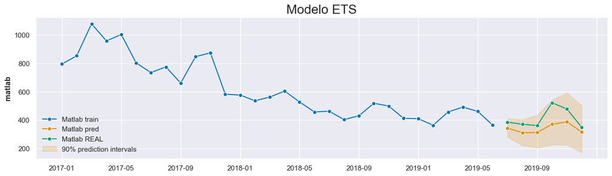

El modelo ETS óptimo es tipo tipo multiplicativo, aditivo, multiplicativo con unos criterios AIC, BIC y HQIC de 1417.907, 1468.960 y 1438.648 respectivamente. Este realiza unas predicciones bastante buenas durante las primeras 3 observaciones del test. Es en las observaciones 4 y 5 del test donde predice peor y la última es la que mejor predice. Como se puede observar, este modelo tiende a ser pesimista a la hora de predecir.

### Modelos ARIMA

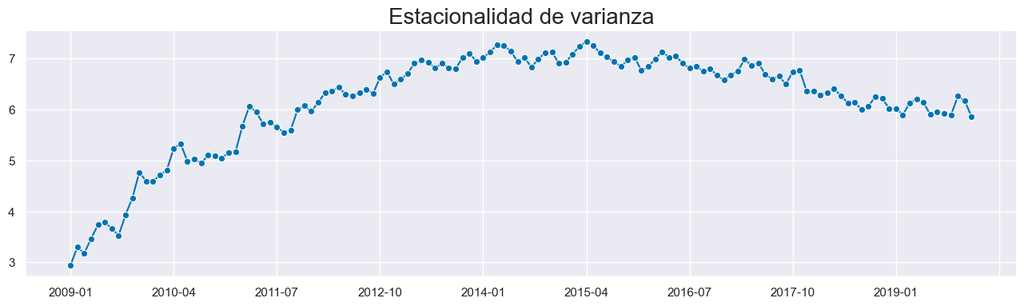

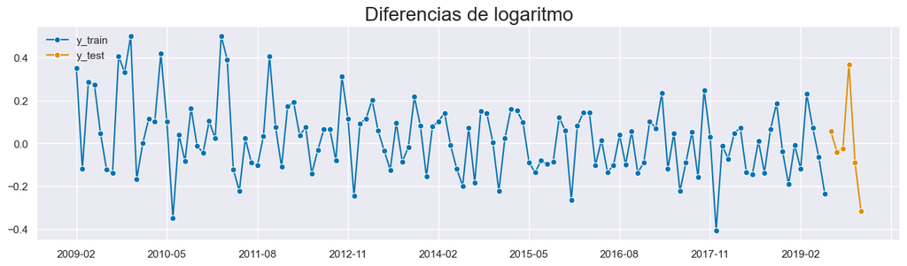

### ARIMA con ambas transformaciones

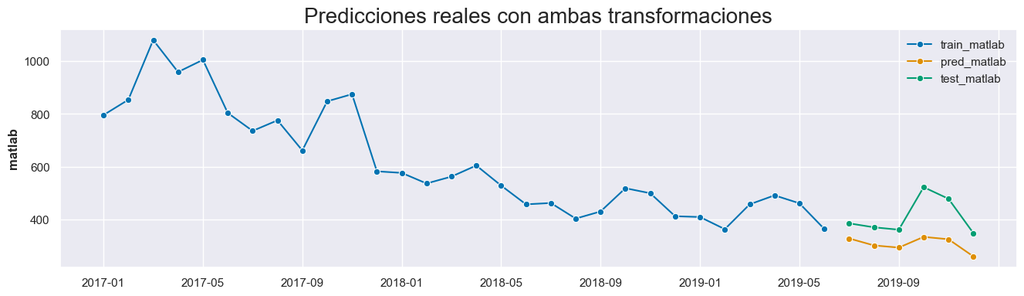

El modelo ARIMA con ambas trasnformaciones tiene una idea similar al modelo ETS. Las predicciones son decentes pero son pesimistas. Al igual que el modelo ETS, es en las observaciones 4 y 5 donde falla más. Por lo general, mantiene la tendencia de los valores del test.

### (EXTRA) ARIMA con transformación en la media

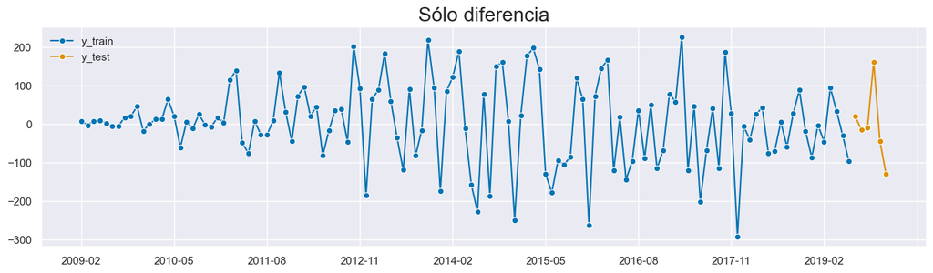

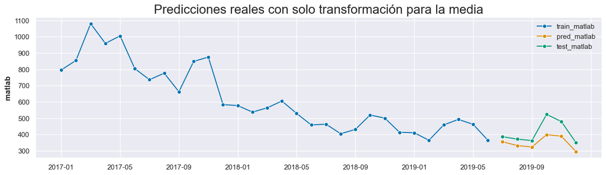

Si realizamos únicamente trasnformación en la media, se puede observar como el modelo es más preciso, obteniendo una línea de predicción mucho más cercana al modelo ARIMA con ambas transformaciones.

### 4Theta

```
(<darts.models.forecasting.theta.FourTheta at 0x7fee5c506ad0>,
 {'theta': 0.8888888888888893,
  'model_mode': <ModelMode.ADDITIVE: 'additive'>,
  'season_mode': <SeasonalityMode.ADDITIVE: 'additive'>,
  'trend_mode': <TrendMode.EXPONENTIAL: 'exponential'>},
 18.713270856289736)
```

Aplico un grid search de tal manera que obtenemos los parámetros óptimos para el modelo Theta. Estos son modo aditivo, modo estacional aditivo y modo tendencial exponencial.

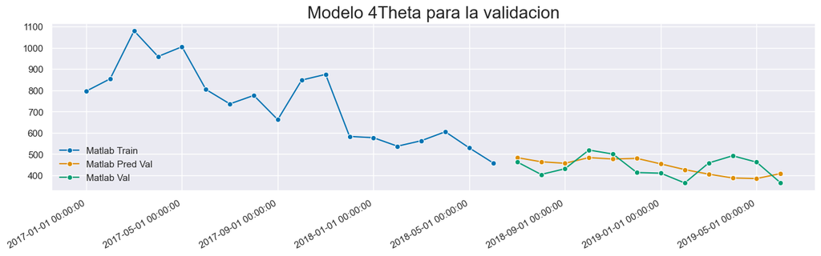

Si calculamos las predicciones del 4Theta con la validación, podemos observar como estas son más precisas ya que no se desvían ni por arriba no por abajo de la línea de los valores de validación. Sin embargo, aunque estas predicciones nos puedan dar unos errores más bajos ya que suavizan más, estas no siguen la tendencia de los valores reales.

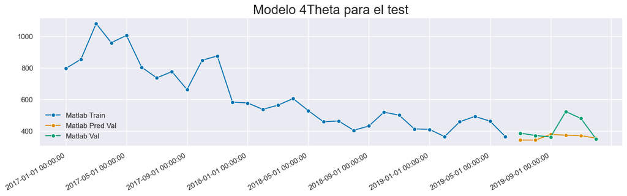

Si realizamos las predicciones sobre nuestra muestra de test, observamos que este suavizamiento en ellos perjudica al modelo ya que no detecta la gran subida en octubre de 2019 ni la bajada posterior. Como conlusión final, el modelo 4theta da unas predicciones muy suavizadas. Pese a que estas predicciones puedan tener unos errores más bajos, no se ajusta bien a los valores reales.